# Albacore Case Study

## Global Albacore Case Study

An Opportunity to collaborate across RFMOs

- Conduct comparative studies
- Share experience
- Provides a test bed for method development to allow
  - Rigorous, transparent, and replicable testing of methods and software.

## Outcomes

Improved collaboration

- Common Dialogue
- New models and software
- Interdisciplinary work

Joint papers

- Case studies for scientific committees
- Peer review papers on methods

## Stocks and Assessments

## Stocks and Assessments

|  | Multifan-CL | SS | Biomass Dynamic | Data Poor |
| --- | --- | --- | --- | --- |
| North Atlantic | x |  | x |  |
| South Atlantic |  |  | x |  |
| Mediterranean |  |  |  | x |
| Indian Ocean |  | x |  |  |
| North Pacific |  | x |  |  |
| South Pacific | x |  |  |  |

## Operating Models

## Operating Models

Operating Models are conditioned on data and knowledge

- Scenarios need to be selected then weighted or rejected.

Are there some sources of uncertainty that are

- More important?
- Redundant?
- Irrelevant?

## Stock Assessment

The provision of fisheries management advice requires

- The assessment of stock status relative to reference points,
- The prediction of the response of a stock to management, and
- Checking that the predictions are consistent with reality.

## Kobe Advice Framework

### **Kobe Phase Plot**

Status relative to reference point with estimation error

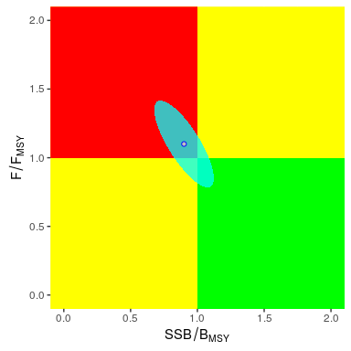

## Model Error

\(2\times 2\times 2\times 2\times 2\times 3\times 3\times 5 =1440\)

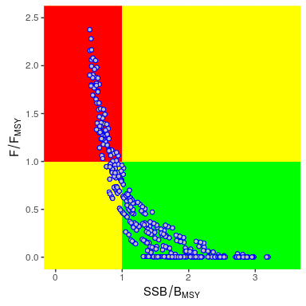

## value uncertainty

### \(~M=0.4?\)

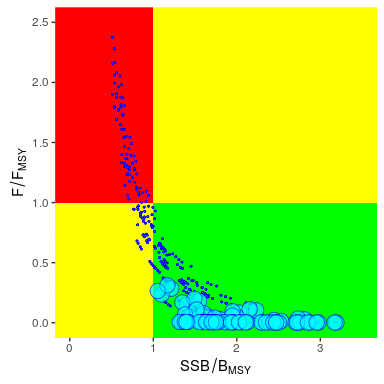

## value uncertainty

### \(~M=0.4, ~~ Steepness=0.9\)

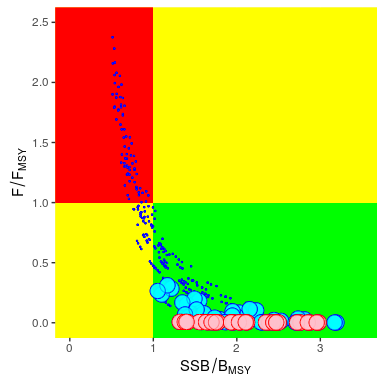

## Uncertainty, Risk and Robustness

### Risk is an Uncertainty that matters

- Can we reduce uncertainty by
  - estimating, steepness, M, … or
  - improving process knowledge

## Experimental design

### The Uncertainty grid

\(2\times 2\times 2\times ...\)

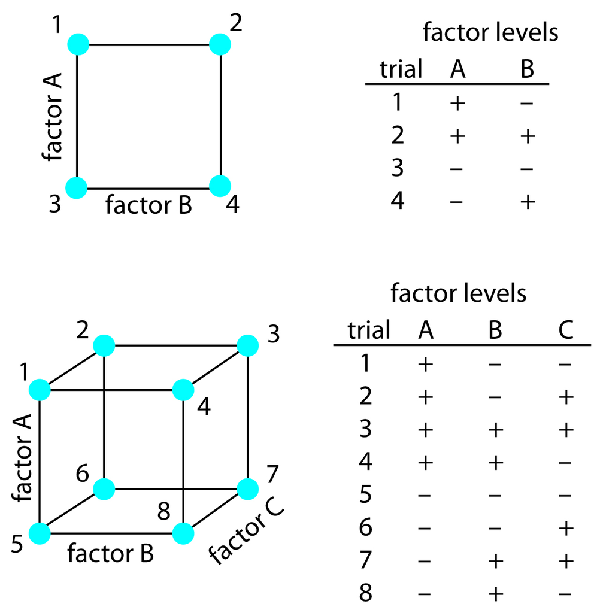

## Principal Compenents Analysis

### How different are the scenarios?

90% of the summary statistics variance can be explained in 2Ds

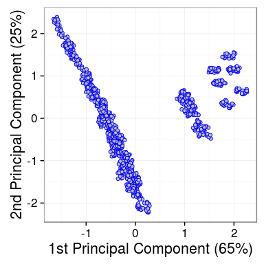

## Principal Compenents Analysis

### Original variables

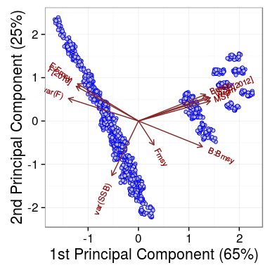

1st axis is mainly \(K\) and 2nd \(r\), with some correlation

## Uncertainty, Risk and Robustness

### Is there a robust control option?

One that still functions correctly despite uncertainty

- \(F_{2016}/F_{MSY}\), \(B_{2016}/B_{MSY}\)
- \(\dfrac{\text{d}F}{\text{d}t}\),\(\dfrac{\text{d}B}{\text{d}t}\)
- \(I_{2016}\),\(\dfrac{\text{d}I}{\text{d}t}\), \(I_{2016}-\frac{\sum_{y=t}^{t+n} (I_y)}{n+1}\)

## Principal Compenents Analysis

### \(Steepness=0.9\)

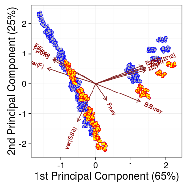

## Principal Compenents Analysis

### \(~M=0.4, ~~ Steepness=0.9\)

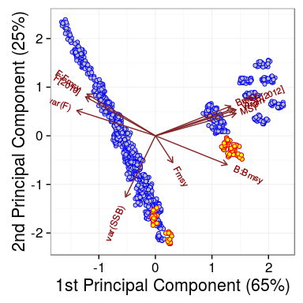

## Meta-analyses

### K Global habitat estimates

- Allowed some hypotheses to be rejected or down weighted
- Changes in productivity?
- Mediterranean Albacore assessment

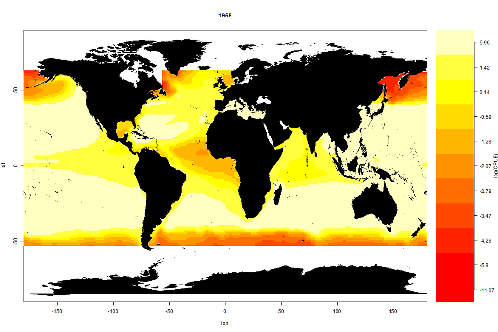

## Prediction skill

## Prediction skill

An Operating Model is a mathematical siumulation model used to project forward. OMs are commonly conditioned using a stock assessment model on historical data, however, in MSE the focus is on the future not the past.

The major uncertainty in stock assessment models is the difference between models and reality. Validation of predictions are difficult for fish stocks, however, without draining oceans.

- Hindcasting and model-free validation can be used to evaluate multiple measures of prediction skill.
- In a hindcast a model is fitted to the first part of a time series and then projected over the period omitted in the original fit.
- Prediction skill can then be evaluated by comparing predictions from a projection with future observations observations.

## Hindcast

Stock assessments use a variety of data types and sets, and statistical stock assessment models have been developed as an attempt to integrate multiple diverse datasets in order to extract as much information as possible

- Datasets are often conflicting and scenarios that reflect a range of hypotheses need to be developed and scenarios to be weighted or rejected.
- Can not use AIC to compare models when datasets change

## Hindcast

### Objectives

Evaluate the prediction skill of scenarios, using a range of data types, assessment models, i.e. biomass, size based, age based, integrated and state space.

- Indentify the main uncertainies for including in OMs.
- Use multiple measures to help understand the error structure of signals to construct Observation Error Models.
- Identify datasets with the best signal to noise ratio for use in Management Procedures

## Benchmarking

## Albacore dataset

### Activities

Collaborative papers on

- Design of sparse uncertainty grids
- Crossvalidation to identify main uncertainties
- Use of K as a prior
- Comparison of HCRs